# **Network Stock Portfolio Optimization**

## Missing Data due to Index Rebalancing

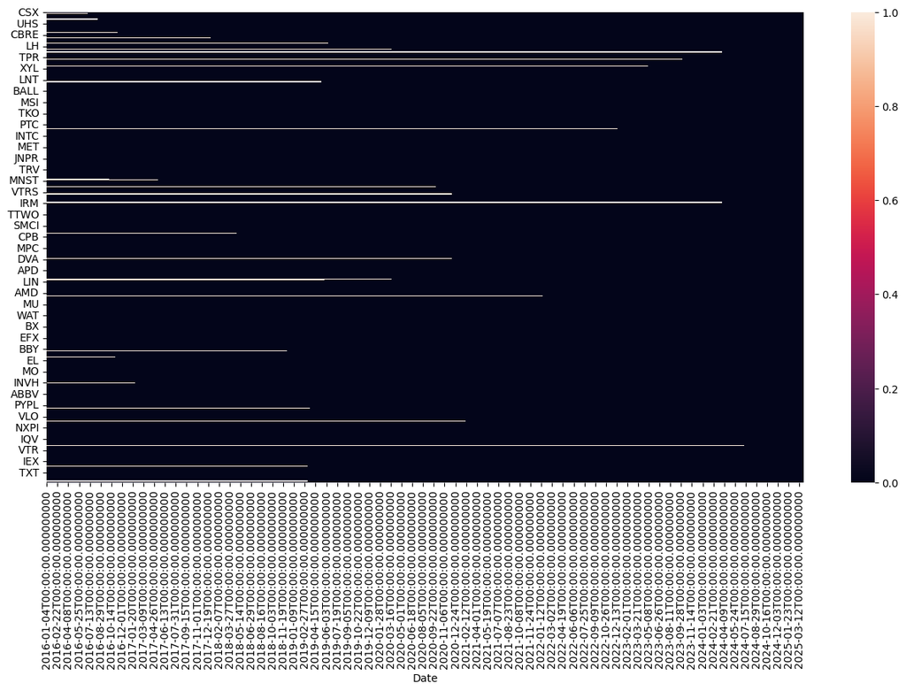

```python
figure = plt.figure(figsize=(16, 8))
sns.heatmap(price_data.T.isnull());
```

The missing data is due to the fact that certain stocks may move out of the S&P 500 and certain stocks may enter the S&P 500 in this respective timeframe.|

```python
price_data_cleaned = price_data.dropna(axis=1) # dropping na values columnwise
```

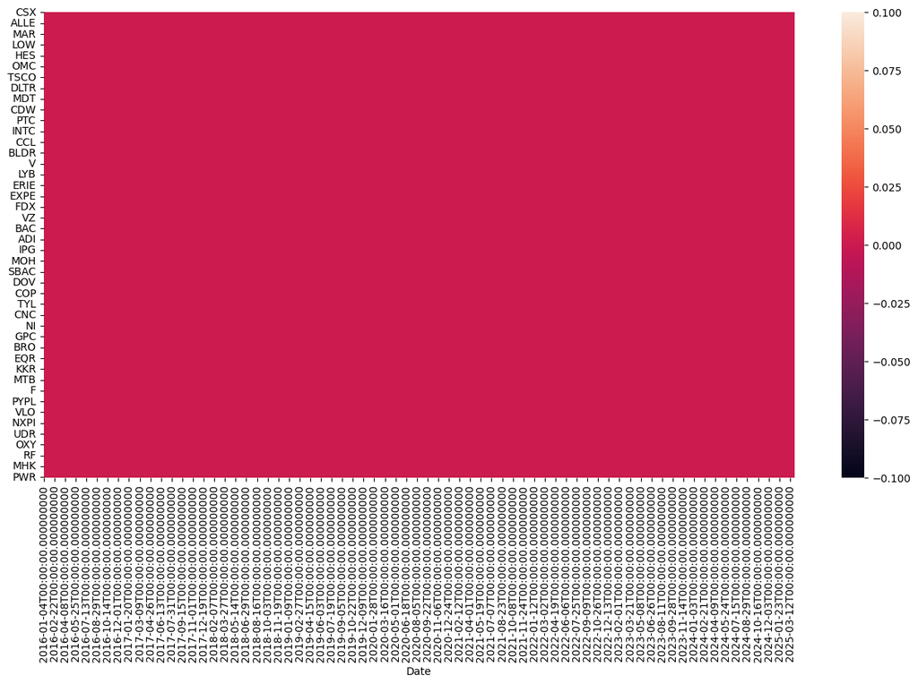

```python
figure = plt.figure(figsize=(16, 8))
sns.heatmap(price_data_cleaned.T.isnull());
```

The null values are removed - the data is clean and the plot also helps in finding that there are no missing values.

## Getting Yearwise Data

```python
def get_year_wise_snp_500_data(data, year):
    year_wise_data = data.loc['{}-01-01'.format(year):'{}-12-31'.format(year)]

    return year_wise_data
```

```python
snp_500_2016 = get_year_wise_snp_500_data(price_data_cleaned, 2016)
snp_500_2017 = get_year_wise_snp_500_data(price_data_cleaned, 2017)
snp_500_2018 = get_year_wise_snp_500_data(price_data_cleaned, 2018)
snp_500_2019 = get_year_wise_snp_500_data(price_data_cleaned, 2019)
snp_500_2020 = get_year_wise_snp_500_data(price_data_cleaned, 2020)
snp_500_2021 = get_year_wise_snp_500_data(price_data_cleaned, 2021)
snp_500_2022 = get_year_wise_snp_500_data(price_data_cleaned, 2022)
snp_500_2023 = get_year_wise_snp_500_data(price_data_cleaned, 2023)
#snp_500_2024 = get_year_wise_snp_500_data(price_data_cleaned, 2024)
```

```python
snp_500_2016
```

| Date | CSX | MKTX | ETR | STLD | DOC | TSN | ZTS | CTSH | PLD | HIG | ... | TXT | PCG | ICE | DUK | RMD | CRL | ALB | JKHY | FSLR | PWR |
| --- | --- | --- | --- | --- | --- | --- | --- | --- | --- | --- | --- | --- | --- | --- | --- | --- | --- | --- | --- | --- | --- |
| 2016-01-04 | 7.496589 | 101.061874 | 28.680269 | 14.616446 | 21.596018 | 42.694954 | 44.148926 | 52.189838 | 32.282173 | 34.873112 | ... | 40.946850 | 49.882313 | 44.642887 | 48.451260 | 46.720024 | 78.250000 | 49.146961 | 68.571762 | 66.720001 | 19.937197 |
| 2016-01-05 | 7.421012 | 101.810944 | 28.835005 | 14.649369 | 22.064878 | 42.162884 | 44.840065 | 52.189838 | 32.960186 | 35.428600 | ... | 41.045506 | 49.957684 | 45.742126 | 48.798351 | 46.925835 | 78.000000 | 48.394936 | 69.575317 | 72.029999 | 19.102800 |
| 2016-01-06 | 7.083823 | 100.580963 | 28.650999 | 14.402469 | 21.177994 | 42.130627 | 44.849415 | 51.292034 | 32.782970 | 34.505508 | ... | 39.812172 | 49.675018 | 45.333683 | 48.907242 | 45.995197 | 76.389999 | 46.280418 | 69.629059 | 69.519997 | 19.083170 |
| 2016-01-07 | 6.865817 | 99.008781 | 28.245338 | 14.139103 | 20.613098 | 42.058071 | 43.485794 | 50.852108 | 31.927763 | 33.655949 | ... | 38.993225 | 49.430035 | 45.136559 | 48.458065 | 46.406822 | 78.519997 | 44.192455 | 68.885361 | 66.220001 | 18.572714 |
| 2016-01-08 | 6.825121 | 97.778816 | 28.236971 | 13.620617 | 20.556614 | 42.162884 | 42.850697 | 50.062035 | 31.642704 | 33.206657 | ... | 38.549213 | 49.053139 | 44.443989 | 48.349171 | 46.639484 | 78.949997 | 43.360790 | 68.500092 | 65.620003 | 18.356749 |
| ... | ... | ... | ... | ... | ... | ... | ... | ... | ... | ... | ... | ... | ... | ... | ... | ... | ... | ... | ... | ... | ... |
| 2016-12-23 | 10.932924 | 139.272751 | 30.482723 | 30.974813 | 19.258068 | 50.953472 | 50.650452 | 50.717438 | 41.285133 | 40.194492 | ... | 48.385666 | 59.022011 | 51.099293 | 55.115730 | 56.676682 | 75.699997 | 79.858459 | 81.168060 | 32.619999 | 34.171043 |
| 2016-12-27 | 10.995566 | 139.337982 | 30.532904 | 31.058599 | 19.330467 | 50.863876 | 50.593945 | 50.834141 | 41.516491 | 40.194492 | ... | 48.484524 | 59.012367 | 51.512997 | 55.016319 | 56.521362 | 76.040001 | 80.029282 | 81.258812 | 33.990002 | 34.396832 |
| 2016-12-28 | 10.894141 | 138.349960 | 30.106331 | 30.621258 | 19.093515 | 50.220337 | 50.330231 | 50.412167 | 41.125561 | 39.761303 | ... | 47.970417 | 58.419228 | 50.946419 | 54.696774 | 56.356888 | 75.599998 | 77.844475 | 80.695976 | 32.799999 | 33.788200 |
| 2016-12-29 | 10.807632 | 135.646927 | 30.737814 | 30.495117 | 19.323883 | 50.627651 | 50.499760 | 50.439102 | 41.699978 | 39.752979 | ... | 48.029747 | 59.401302 | 50.802532 | 55.399750 | 57.051296 | 76.080002 | 78.285004 | 80.959244 | 32.570000 | 33.955082 |
| 2016-12-30 | 10.718143 | 136.942551 | 30.725275 | 29.923227 | 19.560822 | 50.244778 | 50.414993 | 50.304440 | 42.114826 | 39.694672 | ... | 48.009972 | 59.090153 | 50.739578 | 55.115730 | 56.694969 | 76.190002 | 77.394913 | 80.596115 | 32.090000 | 34.210308 |

252 rows × 474 columns

Shift Data

- shifted data: yesterdays price
- shifting required because interested in daily returns

```python
snp_500_2016.shift(1)
```

| Date | CSX | MKTX | ETR | STLD | DOC | TSN | ZTS | CTSH | PLD | HIG | ... | TXT | PCG | ICE | DUK | RMD | CRL | ALB | JKHY | FSLR | PWR |
| --- | --- | --- | --- | --- | --- | --- | --- | --- | --- | --- | --- | --- | --- | --- | --- | --- | --- | --- | --- | --- | --- |
| 2016-01-04 | NaN | NaN | NaN | NaN | NaN | NaN | NaN | NaN | NaN | NaN | ... | NaN | NaN | NaN | NaN | NaN | NaN | NaN | NaN | NaN | NaN |
| 2016-01-05 | 7.496589 | 101.061874 | 28.680269 | 14.616446 | 21.596018 | 42.694954 | 44.148926 | 52.189838 | 32.282173 | 34.873112 | ... | 40.946850 | 49.882313 | 44.642887 | 48.451260 | 46.720024 | 78.250000 | 49.146961 | 68.571762 | 66.720001 | 19.937197 |
| 2016-01-06 | 7.421012 | 101.810944 | 28.835005 | 14.649369 | 22.064878 | 42.162884 | 44.840065 | 52.189838 | 32.960186 | 35.428600 | ... | 41.045506 | 49.957684 | 45.742126 | 48.798351 | 46.925835 | 78.000000 | 48.394936 | 69.575317 | 72.029999 | 19.102800 |
| 2016-01-07 | 7.083823 | 100.580963 | 28.650999 | 14.402469 | 21.177994 | 42.130627 | 44.849415 | 51.292034 | 32.782970 | 34.505508 | ... | 39.812172 | 49.675018 | 45.333683 | 48.907242 | 45.995197 | 76.389999 | 46.280418 | 69.629059 | 69.519997 | 19.083170 |
| 2016-01-08 | 6.865817 | 99.008781 | 28.245338 | 14.139103 | 20.613098 | 42.058071 | 43.485794 | 50.852108 | 31.927763 | 33.655949 | ... | 38.993225 | 49.430035 | 45.136559 | 48.458065 | 46.406822 | 78.519997 | 44.192455 | 68.885361 | 66.220001 | 18.572714 |
| ... | ... | ... | ... | ... | ... | ... | ... | ... | ... | ... | ... | ... | ... | ... | ... | ... | ... | ... | ... | ... | ... |
| 2016-12-23 | 10.944854 | 139.999802 | 30.603989 | 30.916172 | 19.205406 | 50.293659 | 50.160713 | 50.681503 | 41.404800 | 40.119522 | ... | 48.039619 | 59.108822 | 51.512997 | 55.222229 | 56.302063 | 74.379997 | 79.498825 | 80.714149 | 32.680000 | 34.063065 |
| 2016-12-27 | 10.932924 | 139.272751 | 30.482723 | 30.974813 | 19.258068 | 50.953472 | 50.650452 | 50.717438 | 41.285133 | 40.194492 | ... | 48.385666 | 59.022011 | 51.099293 | 55.115730 | 56.676682 | 75.699997 | 79.858459 | 81.168060 | 32.619999 | 34.171043 |
| 2016-12-28 | 10.995566 | 139.337982 | 30.532904 | 31.058599 | 19.330467 | 50.863876 | 50.593945 | 50.834141 | 41.516491 | 40.194492 | ... | 48.484524 | 59.012367 | 51.512997 | 55.016319 | 56.521362 | 76.040001 | 80.029282 | 81.258812 | 33.990002 | 34.396832 |
| 2016-12-29 | 10.894141 | 138.349960 | 30.106331 | 30.621258 | 19.093515 | 50.220337 | 50.330231 | 50.412167 | 41.125561 | 39.761303 | ... | 47.970417 | 58.419228 | 50.946419 | 54.696774 | 56.356888 | 75.599998 | 77.844475 | 80.695976 | 32.799999 | 33.788200 |
| 2016-12-30 | 10.807632 | 135.646927 | 30.737814 | 30.495117 | 19.323883 | 50.627651 | 50.499760 | 50.439102 | 41.699978 | 39.752979 | ... | 48.029747 | 59.401302 | 50.802532 | 55.399750 | 57.051296 | 76.080002 | 78.285004 | 80.959244 | 32.570000 | 33.955082 |

252 rows × 474 columns